# Biostatistics III in R

Code by Annika Tillander, Andreas Karlsson and Mark Clements

# Exercise 2. Comparing survival proportions and mortality rates by stage for cause-specific and all-cause survival

Load dependencies

```r
library(biostat3) # loads the survival and muhaz packages
library(dplyr)    # for data manipulation
library(bshazard) # for smoothed hazards
library(knitr)    # for html tables
## utility function
as.data.frame.bshazard <- function(x, ...)
    with(x, data.frame(time,hazard,lower.ci,upper.ci))
```

We define two 1/0 variables for the events. We then list the first few observations to get an idea about the data.

```r
## Create 0/1 outcome variables and then show first six rows of the dataset
melanoma <-
    transform(biostat3::melanoma,
              death_cancer = ifelse(status == "Dead: cancer", 1, 0),
              death_all = ifelse(status %in% c("Dead: cancer", "Dead: other"), 1, 0))
head(melanoma) |> knitr::kable("html")
```

| sex | age | stage | mmdx | yydx | surv_mm | surv_yy | status | subsite | year8594 | dx | exit | agegrp | id | ydx | yexit | death_cancer | death_all |
| --- | --- | --- | --- | --- | --- | --- | --- | --- | --- | --- | --- | --- | --- | --- | --- | --- | --- |
| Female | 81 | Localised | 2 | 1981 | 26.5 | 2.5 | Dead: other | Head and Neck | Diagnosed 75-84 | 1981-02-02 | 1983-04-20 | 75+ | 1 | 1981.088 | 1983.298 | 0 | 1 |
| Female | 75 | Localised | 9 | 1975 | 55.5 | 4.5 | Dead: other | Head and Neck | Diagnosed 75-84 | 1975-09-21 | 1980-05-07 | 75+ | 2 | 1975.720 | 1980.348 | 0 | 1 |
| Female | 78 | Localised | 2 | 1978 | 177.5 | 14.5 | Dead: other | Limbs | Diagnosed 75-84 | 1978-02-21 | 1992-12-07 | 75+ | 3 | 1978.140 | 1992.934 | 0 | 1 |
| Female | 75 | Unknown | 8 | 1975 | 29.5 | 2.5 | Dead: cancer | Multiple and NOS | Diagnosed 75-84 | 1975-08-25 | 1978-02-08 | 75+ | 4 | 1975.646 | 1978.104 | 1 | 1 |
| Female | 81 | Unknown | 7 | 1981 | 57.5 | 4.5 | Dead: other | Head and Neck | Diagnosed 75-84 | 1981-07-09 | 1986-04-25 | 75+ | 5 | 1981.517 | 1986.312 | 0 | 1 |
| Female | 75 | Localised | 9 | 1975 | 19.5 | 1.5 | Dead: cancer | Trunk | Diagnosed 75-84 | 1975-09-03 | 1977-04-19 | 75+ | 6 | 1975.671 | 1977.296 | 1 | 1 |

## (a) Plot estimates of the survivor function and hazard function by stage

We now tabulate the distribution of the melanoma patients by cancer stage at diagnosis.

```r
## Tabulate by stage
Freq <- xtabs(~stage, data=melanoma)
cbind(Freq, Prop=proportions(Freq)) |> kable("html")
```

|  | Freq | Prop |
| --- | --- | --- |
| Unknown | 1631 | 0.2097749 |
| Localised | 5318 | 0.6839871 |
| Regional | 350 | 0.0450161 |
| Distant | 476 | 0.0612219 |

We then plot the survival and survival by stage.

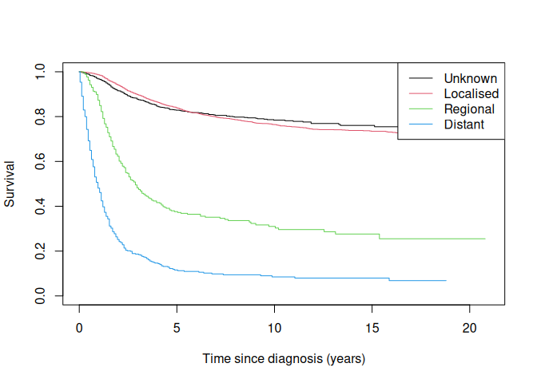

```r
survfit(Surv(surv_mm/12, death_cancer) ~ stage, data = melanoma) |>
    plot(col=1:4,
         xlab = "Time since diagnosis (years)",
         ylab = "Survival")
legend("topright", levels(melanoma$stage), col=1:4, lty = 1)
```

Survival depends heavily on stage. It is interesting to note that patients with stage 0 (unknown) appear to have a similar survival to patients with stage 1 (localized).

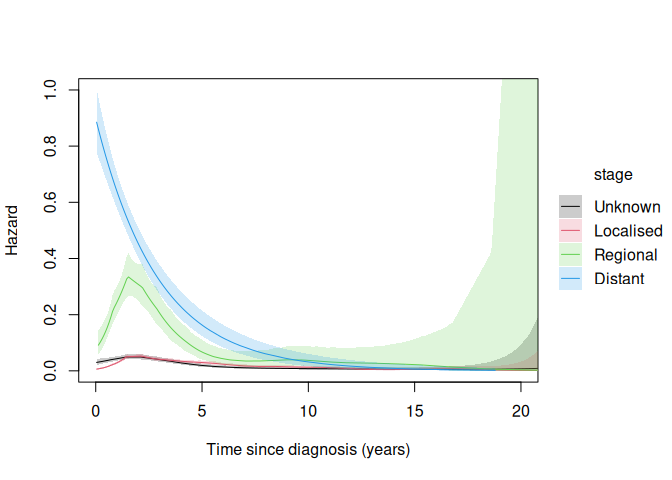

```r
library(dplyr)
hazards <- group_by(melanoma, stage) |>
    do(as.data.frame(bshazard(Surv(surv_mm/12, death_cancer)~1, data=., verbose=FALSE))) |>
    ungroup()
with(hazards, plt(hazard~time|stage, ymin=lower.ci, ymax=upper.ci,
                  type="ribbon",
                  xlab="Time since diagnosis (years)",
                  ylab="Hazard",
                  col=1:4, lty=1, xlim=c(0,20), ylim=0:1))
```

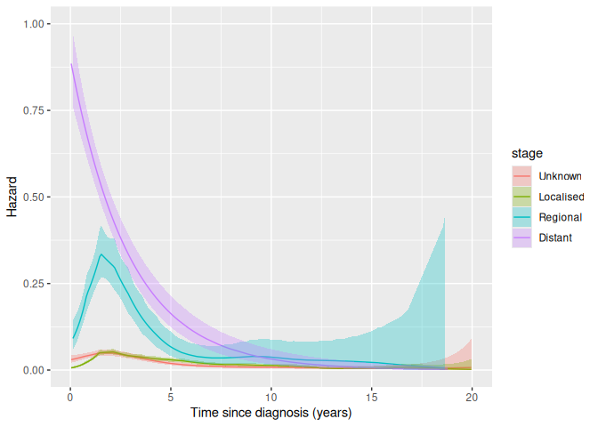

```r
ggplot(hazards,aes(x=time,y=hazard,group=stage)) + geom_line(aes(col=stage)) +
    geom_ribbon(aes(ymin=lower.ci, ymax=upper.ci, fill=stage), alpha=0.3) +
    xlim(0,20) + ylim(0,1) +
    xlab('Time since diagnosis (years)') + ylab('Hazard')
```

As an extension, we can use the`bshazard` to calculate the hazards with confidence intervals (see below). Note, however, that the bshazard function will *adjust* for covariates rather than stratify by covariates. This means that we need to divide the dataset into strata and calculate the smoothed hazards separately. I have shown one approach using `dplyr` for dividing the data, with the plots use `tinyplot` and `ggplot`, which allows for over-lapping confidence intervals (using the `alpha` transparency argument).

## (b) Estimate the mortality rates for each stage using, for example, the `survRate` command

```r
survRate(Surv(surv_mm/12, death_cancer) ~ stage, data=melanoma) |> kable("html")
```

|  | stage | tstop | event | rate | lower | upper |
| --- | --- | --- | --- | --- | --- | --- |
| stage=Unknown | Unknown | 10267.12 | 274 | 0.0266871 | 0.0236204 | 0.0300414 |
| stage=Localised | Localised | 38626.58 | 1013 | 0.0262255 | 0.0246351 | 0.0278915 |
| stage=Regional | Regional | 1500.25 | 218 | 0.1453091 | 0.1266589 | 0.1659324 |
| stage=Distant | Distant | 875.75 | 408 | 0.4658864 | 0.4217712 | 0.5133615 |

The time unit is years (since we specified `surv_mm/12` as the analysis time). Therefore, the units of the rates shown above are events/person-years.

We can also do this using more general tools:

```r
library(dplyr)
melanoma |>
    group_by(stage) |>
    summarise(D = sum(death_cancer), M = sum(surv_mm/12), Rate = D/M,
              CI_low = stats::poisson.test(D,M)$conf.int[1],
              CI_high = stats::poisson.test(D,M)$conf.int[2]) |>
    kable("html")
```

| stage | D | M | Rate | CI_low | CI_high |
| --- | --- | --- | --- | --- | --- |
| Unknown | 274 | 10267.12 | 0.0266871 | 0.0236204 | 0.0300414 |
| Localised | 1013 | 38626.58 | 0.0262255 | 0.0246351 | 0.0278915 |
| Regional | 218 | 1500.25 | 0.1453091 | 0.1266589 | 0.1659324 |
| Distant | 408 | 875.75 | 0.4658864 | 0.4217712 | 0.5133615 |

## (c)

Here we tabulate crude rates per 1000 person-years. For example,

```r
survRate(Surv(surv_mm/12/1000, death_cancer) ~ stage, data=melanoma) |>
    kable("html")
```

|  | stage | tstop | event | rate | lower | upper |
| --- | --- | --- | --- | --- | --- | --- |
| stage=Unknown | Unknown | 10.26713 | 274 | 26.68712 | 23.62045 | 30.04141 |
| stage=Localised | Localised | 38.62658 | 1013 | 26.22546 | 24.63514 | 27.89150 |
| stage=Regional | Regional | 1.50025 | 218 | 145.30912 | 126.65886 | 165.93238 |
| stage=Distant | Distant | 0.87575 | 408 | 465.88638 | 421.77124 | 513.36147 |

## (d)

Below we see that the crude mortality rate is higher for males than for females.

```r
survRate(Surv(surv_mm/12/1000, death_cancer) ~ sex, data=melanoma) |>
    kable("html")
```

|  | sex | tstop | event | rate | lower | upper |
| --- | --- | --- | --- | --- | --- | --- |
| sex=Male | Male | 21.96892 | 1074 | 48.88725 | 46.00684 | 51.90076 |
| sex=Female | Female | 29.30079 | 839 | 28.63404 | 26.72903 | 30.63898 |

We see that the crude mortality rate is higher for males than females, a difference which is also reflected in the survival and hazard curves:

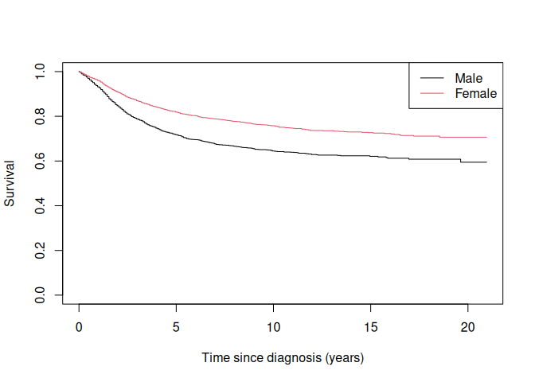

```r
survfit(Surv(surv_mm/12, death_cancer) ~ sex, data = melanoma) |>
    plot(col=1:2,
         xlab = "Time since diagnosis (years)",
         ylab = "Survival")
legend("topright", legend=levels(melanoma$sex), lty=1, col=1:2)
```

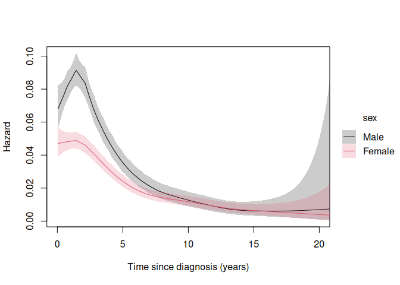

```r
library(dplyr)
hazards <- group_by(melanoma, sex) |>
    do(as.data.frame(bshazard(Surv(surv_mm/12, death_cancer)~1, data=., verbose=FALSE))) |>
    ungroup()
with(hazards, plt(hazard~time|sex, ymin=lower.ci, ymax=upper.ci,
                  type="ribbon",
                  xlab="Time since diagnosis (years)",
                  ylab="Hazard",
                  col=1:2, lty=1, xlim=c(0,20)))
```

## (e)

The majority of patients are alive at end of study. 1,913 died from cancer while 1,134 died from another cause. The cause of death is highly depending of age, as young people die less from other causes. To observe this we tabulate the events by age group.

```r
Freq <- xtabs(~status+agegrp, melanoma)
Freq
```

```
##                    agegrp
## status              0-44 45-59 60-74  75+
##   Alive             1615  1568  1178  359
##   Dead: cancer       386   522   640  365
##   Dead: other         39   147   461  487
##   Lost to follow-up    6     1     1    0
```

```r
round(proportions(Freq,"agegrp")*100,1) # proportions for status by agegrp
```

```
##                    agegrp
## status              0-44 45-59 60-74  75+
##   Alive             78.9  70.1  51.7 29.6
##   Dead: cancer      18.9  23.3  28.1 30.1
##   Dead: other        1.9   6.6  20.2 40.2
##   Lost to follow-up  0.3   0.0   0.0  0.0
```

```r
chisq.test(Freq[-4,])
```

```
##
##  Pearson's Chi-squared test
##
## data:  Freq[-4, ]
## X-squared = 1341.4, df = 6, p-value < 2.2e-16
```

## (f)

The survival is worse for all-cause survival than for cause-specific, since you now can die from other causes, and these deaths are incorporated in the Kaplan-Meier estimates. The ”other cause” mortality is particularly present in patients with localised and unknown stage.

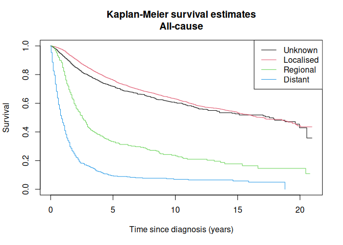

```r
par(mfrow=c(1, 1))
survfit(Surv(surv_mm/12, death_all) ~ stage, data = melanoma) |>
    plot(col=1:4,
         xlab = "Time since diagnosis (years)",
         ylab = "Survival",
         main = "Kaplan-Meier survival estimates\nAll-cause")
legend("topright", levels(melanoma$stage), col=1:4, lty = 1)
```

## (g)

By comparing Kaplan-Meier estimates for cancer deaths with all-cause mortality conditioned on age over 75 years, we see that the “other” cause mortality is particularly influential in patients with localised and unknown stage. Patients with localised disease, have a better prognosis (i.e. the cancer does not kill them), and are thus more likely to experience death from another cause. For regional and distant stage, the cancer is more aggressive and is the cause of death for most of these patients (i.e. it is the cancer that kills these patients before they have “the chance” to die from something else).

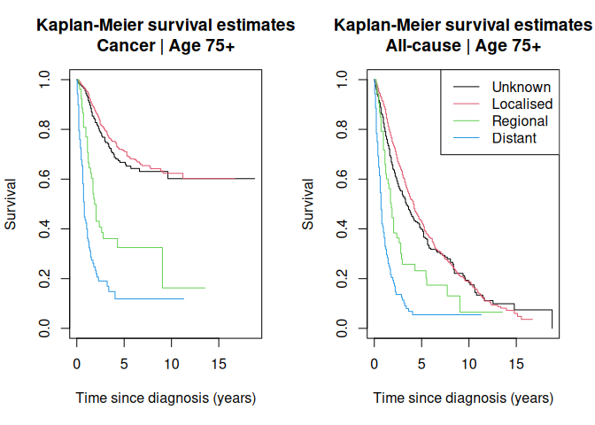

```r
par(mfrow=c(1, 2))
survfit(Surv(surv_mm/12, death_cancer) ~ stage, data = subset(melanoma,agegrp=="75+")) |>
    plot(col=1:4,
         xlab = "Time since diagnosis (years)",
         ylab = "Survival",
         main = "Kaplan-Meier survival estimates\nCancer | Age 75+")
survfit(Surv(surv_mm/12, death_all) ~ stage, data = subset(melanoma,agegrp=="75+")) |>
    plot(col=1:4,
         xlab = "Time since diagnosis (years)",
         ylab = "Survival",
         main = "Kaplan-Meier survival estimates\nAll-cause | Age 75+")
legend("topright", levels(melanoma$stage), col=1:4, lty = 1)
```

## (h) Compare Kaplan-Meier estimates for cancer deaths with all-cause mortality by age group.

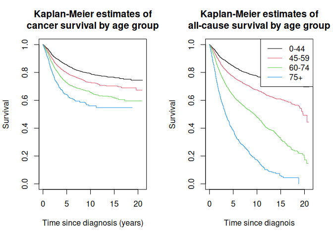

```r
par(mfrow=c(1, 2))
survfit(Surv(surv_mm/12, death_cancer) ~ agegrp, data = melanoma) |>
    plot(col=1:4,
         xlab = "Time since diagnosis (years)",
         ylab = "Survival",
         main = "Kaplan-Meier estimates of\ncancer survival by age group")
survfit(Surv(surv_mm/12, death_all) ~ agegrp, data = melanoma) |>
    plot(col=1:4,
         xlab = "Time since diagnois",
         ylab = "Survival",
         main = "Kaplan-Meier estimates of\nall-cause survival by age group")
legend("topright", levels(melanoma$agegrp), col=1:4, lty = 1)
```